# Reseñas de vinos: calidad, precio y descriptores de sabor

- Mostrar todo el código
- Ocultar todo el código
- Ver el código fuente

Proyecto Final: Ciencia de Datos con R y Python

Autor/a

Fecha de publicación

12 de noviembre de 2026

# 1 Introducción

## 1.1 Contexto

Las reseñas de vinos de revistas especializadas influyen en las decisiones de compra y en el precio de las botellas. Este proyecto analiza más de 150 mil reseñas con dos preguntas centrales: **qué relación existe entre el precio y la puntuación**, y **qué características distinguen a los vinos mejor valorados**.

## 1.2 Preguntas de investigación

1. ¿Qué países y variedades obtienen mejores puntuaciones y a qué precio?
2. ¿Existe relación entre el precio y la puntuación? ¿Cuánto cuesta ganar puntos adicionales?
3. ¿Qué variedades ofrecen mejor relación calidad-precio?
4. ¿Qué palabras de la descripción se asocian a puntuaciones altas y bajas?
5. ¿Difiere significativamente la puntuación entre países?

# 2 Datos

## 2.1 Origen y licencia

- **Fuente:** *Wine Reviews*, Kaggle (datos de WineEnthusiast, recopilados por Zack Thoutt). Archivo `winemag-data_first150k.csv`.
- **URL:** https://www.kaggle.com/datasets/zynicide/wine-reviews
- **Licencia:** verificar en la página del dataset (publicado bajo CC BY-NC-SA 4.0 en Kaggle) y uso estrictamente académico.
- **Trazabilidad:** el archivo se incluye en `data/raw/` y todo el procesamiento se ejecuta con `scripts/01_ingesta_limpieza.py`.

## 2.2 Estructura

Cada fila es una reseña. Variables originales: `country`, `description`, `designation`, `points`, `price`, `province`, `region_1`, `region_2`, `variety`, `winery` y un índice heredado del CSV.

## 2.3 Limitaciones y sesgos

- **Sesgo de selección:** solo aparecen vinos con 80 puntos o más; no hay vinos “malos”.
- **Una sola fuente de críticos:** las puntuaciones reflejan los criterios de un único medio.
- **Sobrerrepresentación de EE. UU.** y de Europa occidental.
- **Sin fecha:** no hay añada ni fecha de reseña, por lo que no hay análisis temporal; los precios están en USD sin año de referencia.
- **Precio faltante** en ~9 % de las reseñas.

# 3 Metodología y preparación de datos (Python)

Se utilizó **Python** para la ingesta, limpieza y procesamiento de texto (pandas, scikit-learn) y **R** para el análisis estadístico y las visualizaciones (tidyverse, rstatix, ggplot2).

## 3.1 Ejecución de la limpieza

**Código**

```python
import subprocess, sys
from pathlib import Path
import pandas as pd

root = Path("..").resolve()
res = subprocess.run([sys.executable, "scripts/01_ingesta_limpieza.py"],
                     cwd=root, capture_output=True, text=True)
print(res.stdout[-1500:])
```

```
Filas: 150930 -> 97821 (53109 eliminadas)
                      paso  filas_antes  filas_despues  afectadas                                          nota
   Eliminar columna índice       150930         150930          0              Unnamed: 0 no aporta información
        Duplicados exactos       150930          97851      53079       Todas las columnas iguales (sin índice)
Duplicados por descripción        97851          97821         30 Misma reseña repetida: no son vinos distintos
```

**Código**

```python
if res.returncode != 0:
    raise RuntimeError(res.stderr)
```

## 3.2 Bitácora de decisiones

**Código**

```python
log = pd.read_csv(root / "data/processed/cleaning_log.csv")
log
```

```
                         paso  ...                                           nota
0     Eliminar columna índice  ...               Unnamed: 0 no aporta información
1          Duplicados exactos  ...        Todas las columnas iguales (sin índice)
2  Duplicados por descripción  ...  Misma reseña repetida: no son vinos distintos

[3 rows x 5 columns]
```

**Decisiones y justificación:**

| Decisión | Justificación |
| --- | --- |
| Eliminar la columna índice | El índice hacía que ninguna fila pareciera duplicada; al quitarlo aparecen más de 53.000 duplicados exactos. |
| Eliminar duplicados por `description` | Una misma reseña repetida no representa un vino distinto y sesga los promedios. |
| Descartar `region_2` | Cerca de 60 % de valores faltantes. |
| No imputar `price` | Imputar sesgaría la relación precio-puntos; se conserva el indicador `has_price`. |
| Trabajar con `log(price)` | El precio tiene una cola muy larga (4 a 2.300 USD). |
| Marcar outliers (IQR sobre log-precio) sin eliminarlos | Son vinos de lujo reales; se evalúa la sensibilidad de los resultados. |

## 3.3 Variables derivadas

- `price_segment`: Económico, Medio, Premium, Lujo.
- `points_band`: 80-84, 85-89, 90-94, 95-100.
- `value_score`: puntos observados menos puntos esperados para su precio (residuo de la regresión `points ~ log(price)`). Valores positivos indican mejor relación calidad-precio.
- `desc_len`: número de palabras de la descripción.
- `variety_top`: 20 variedades más frecuentes y “Otras”.

# 4 Análisis exploratorio (R)

**Código**

```r
wine <- read_csv("../data/processed/wine_clean.csv", show_col_types = FALSE) |>
  mutate(points_band = factor(points_band, levels = c("80-84","85-89","90-94","95-100")),
         price_segment = factor(price_segment,
           levels = c("Económico (<=15)","Medio (15-30)","Premium (30-60)","Lujo (>60)")))

stopifnot(nrow(wine) > 5000, all(wine$points >= 80 & wine$points <= 100))
glimpse(wine)
```

```
Rows: 97,821
Columns: 17
$ country       <chr> "US", "Spain", "US", "US", "France", "Spain", "Spain", "…
$ description   <chr> "This tremendous 100% varietal wine hails from Oakville …
$ designation   <chr> "Martha's Vineyard", "Carodorum Selección Especial Reser…
$ points        <dbl> 96, 96, 96, 96, 95, 95, 95, 95, 95, 95, 95, 95, 95, 95, …
$ price         <dbl> 235, 110, 90, 65, 66, 73, 65, 110, 65, 60, 80, 48, 48, 9…
$ province      <chr> "California", "Northern Spain", "California", "Oregon", …
$ region_1      <chr> "Napa Valley", "Toro", "Knights Valley", "Willamette Val…
$ variety       <chr> "Cabernet Sauvignon", "Tinta de Toro", "Sauvignon Blanc"…
$ winery        <chr> "Heitz", "Bodega Carmen Rodríguez", "Macauley", "Ponzi",…
$ has_price     <lgl> TRUE, TRUE, TRUE, TRUE, TRUE, TRUE, TRUE, TRUE, TRUE, TR…
$ log_price     <dbl> 5.459586, 4.700480, 4.499810, 4.174387, 4.189655, 4.2904…
$ price_outlier <lgl> TRUE, FALSE, FALSE, FALSE, FALSE, FALSE, FALSE, FALSE, F…
$ price_segment <fct> Lujo (>60), Lujo (>60), Lujo (>60), Lujo (>60), Lujo (>6…
$ points_band   <fct> 95-100, 95-100, 95-100, 95-100, 95-100, 95-100, 95-100, …
$ desc_len      <dbl> 60, 51, 47, 62, 66, 52, 50, 60, 42, 45, 54, 40, 46, 54, …
$ value_score   <dbl> 1.6206322627, 3.8645251739, 4.4577019584, 5.4196411826, …
$ variety_top   <chr> "Cabernet Sauvignon", "Otras", "Sauvignon Blanc", "Pinot…
```

## 4.1 Estadísticas descriptivas

**Código**

```r
wine |>
  summarise(across(c(points, price, desc_len),
                   list(media = ~mean(.x, na.rm = TRUE), mediana = ~median(.x, na.rm = TRUE),
                        sd = ~sd(.x, na.rm = TRUE), min = ~min(.x, na.rm = TRUE),
                        max = ~max(.x, na.rm = TRUE)))) |>
  pivot_longer(everything(), names_to = c("variable", "stat"), names_sep = "_(?=[^_]+$)") |>
  pivot_wider(names_from = stat, values_from = value) |>
  kable(digits = 2)
```

| variable | media | mediana | sd | min | max |
| --- | --- | --- | --- | --- | --- |
| points | 87.96 | 88 | 3.22 | 80 | 100 |
| price | 33.66 | 25 | 37.67 | 4 | 2300 |
| desc_len | 40.06 | 39 | 11.67 | 3 | 135 |

**Código**

```r
wine |> summarise(across(everything(), ~mean(is.na(.x)))) |>
  pivot_longer(everything(), names_to = "variable", values_to = "pct_na") |>
  filter(pct_na > 0) |>
  kable(digits = 3, caption = "Proporción de valores faltantes tras la limpieza")
```

Proporción de valores faltantes tras la limpieza

| variable | pct_na |
| --- | --- |
| country | 0.000 |
| price | 0.089 |
| province | 0.000 |
| log_price | 0.089 |
| price_segment | 0.089 |
| value_score | 0.089 |

## 4.2 Distribuciones

**Código**

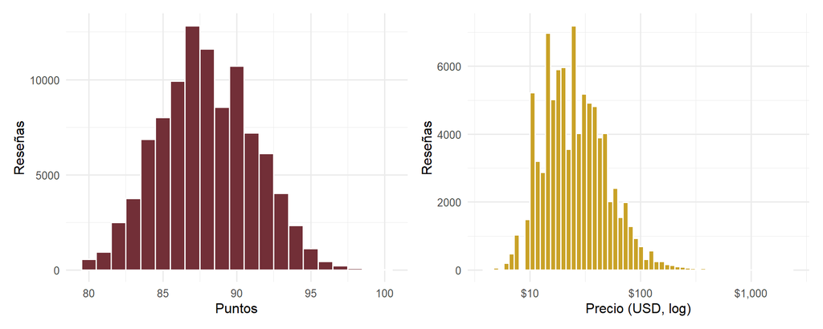

Figura 1: Distribución de puntos (izquierda) y precio en escala logarítmica (derecha).

```r
library(patchwork)
p1 <- ggplot(wine, aes(points)) + geom_histogram(binwidth = 1, fill = "#722F37", colour = "white") +
  labs(x = "Puntos", y = "Reseñas")
p2 <- ggplot(wine, aes(price)) + geom_histogram(bins = 60, fill = "#C9A227", colour = "white", na.rm = TRUE) +
  scale_x_log10(labels = dollar) + labs(x = "Precio (USD, log)", y = "Reseñas")
p1 + p2
```

Los puntos se concentran entre 85 y 91 con un mínimo en 80 (efecto del sesgo de selección). El precio es muy asimétrico: la mediana ronda los 25 USD pero hay vinos de más de 2.000 USD.

## 4.3 Países y variedades

**Código**

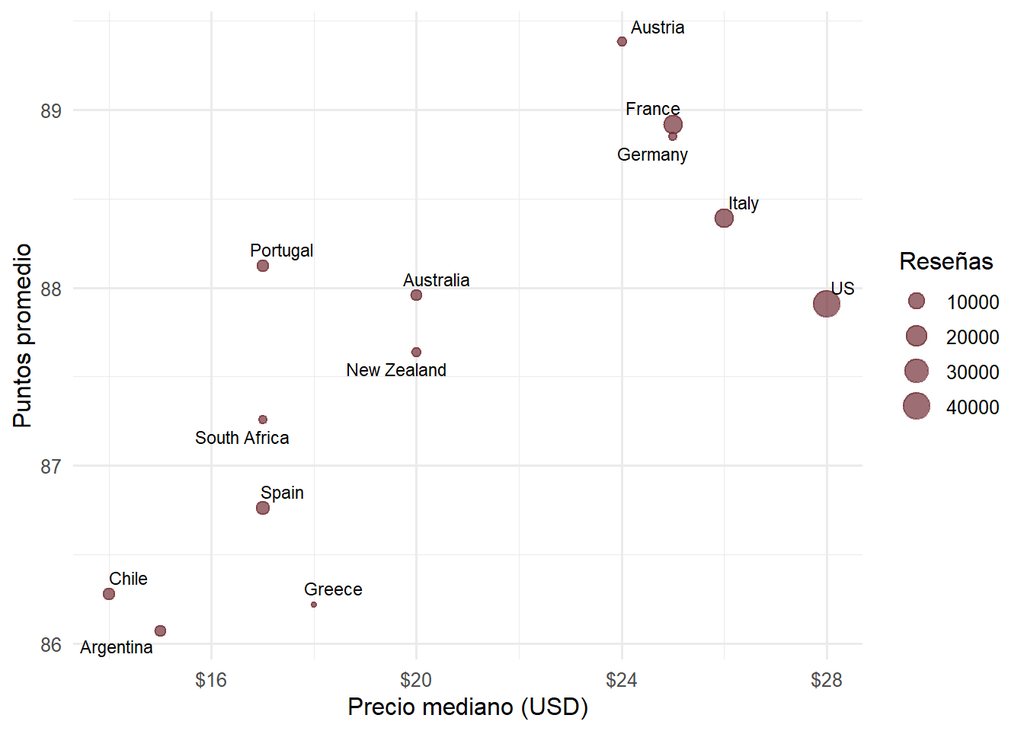

Figura 2: Puntuación media y precio mediano por país (países con al menos 500 reseñas).

```r
wine |>
  group_by(country) |>
  summarise(n = n(), pts = mean(points), precio = median(price, na.rm = TRUE)) |>
  filter(n >= 500) |>
  ggplot(aes(precio, pts, size = n, label = country)) +
  geom_point(colour = "#722F37", alpha = .7) +
  ggrepel::geom_text_repel(size = 3, show.legend = FALSE) +
  scale_x_continuous(labels = dollar) +
  labs(x = "Precio mediano (USD)", y = "Puntos promedio", size = "Reseñas")
```

**Código**

```r
wine |>
  filter(!is.na(value_score)) |>
  group_by(variety) |>
  summarise(n = n(), puntos = mean(points), precio_mediano = median(price), valor = mean(value_score)) |>
  filter(n >= 100) |>
  slice_max(valor, n = 10) |>
  kable(digits = 2)
```

Tabla 1: Variedades con mejor relación calidad-precio (mínimo 100 reseñas).

| variety | n | puntos | precio_mediano | valor |
| --- | --- | --- | --- | --- |
| Portuguese Red | 1153 | 88.80 | 16 | 1.87 |
| Grüner Veltliner | 578 | 89.20 | 21 | 1.70 |
| Blaufränkisch | 120 | 89.37 | 24 | 1.55 |
| Muscat | 107 | 88.70 | 18 | 1.28 |
| Touriga Nacional | 101 | 88.64 | 21 | 1.15 |
| Chenin Blanc | 396 | 87.86 | 16 | 1.14 |
| Portuguese White | 465 | 86.94 | 12 | 1.11 |
| Riesling | 3384 | 88.62 | 20 | 1.05 |
| Sémillon | 142 | 88.06 | 20 | 0.90 |
| Sangiovese Grosso | 629 | 90.82 | 55 | 0.79 |

## 4.4 Relación precio-puntuación

**Código**

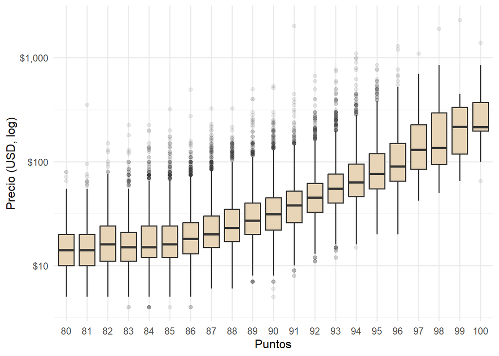

Figura 3: Precio (escala log) según puntuación. La relación es positiva pero con rendimientos decrecientes.

```r
wine |> filter(!is.na(price)) |>
  ggplot(aes(factor(points), price)) +
  geom_boxplot(fill = "#E8D5B7", outlier.alpha = .1) +
  scale_y_log10(labels = dollar) +
  labs(x = "Puntos", y = "Precio (USD, log)")
```

**Código**

```r
wine |> filter(!is.na(price)) |> cor_test(points, log_price, method = "spearman")
```

```
# A tibble: 1 × 6
  var1   var2        cor statistic     p method
  <chr>  <chr>     <dbl>     <dbl> <dbl> <chr>
1 points log_price   0.6   4.73e13     0 Spearman
```

**Código**

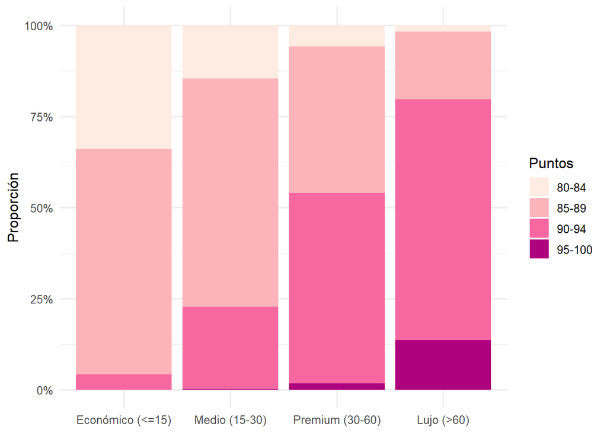

Figura 4: Composición de cada segmento de precio por banda de puntuación.

```r
wine |> filter(!is.na(price_segment)) |>
  count(price_segment, points_band) |>
  group_by(price_segment) |> mutate(p = n / sum(n)) |>
  ggplot(aes(price_segment, p, fill = points_band)) +
  geom_col() + scale_y_continuous(labels = percent) +
  scale_fill_brewer(palette = "RdPu") +
  labs(x = NULL, y = "Proporción", fill = "Puntos")
```

## 4.5 Longitud de la descripción

**Código**

```r
wine |> group_by(points_band) |> summarise(palabras_medias = mean(desc_len)) |> kable(digits = 1)
```

| points_band | palabras_medias |
| --- | --- |
| 80-84 | 31.3 |
| 85-89 | 38.7 |
| 90-94 | 45.7 |
| 95-100 | 54.8 |

# 5 Análisis inferencial

## 5.1 ¿Difiere la puntuación entre países?

Se comparan los 8 países con más reseñas. Dado que `points` es ordinal y no normal, se emplea la prueba de Kruskal-Wallis con post-hoc de Dunn (Bonferroni).

**Código**

```r
top8 <- wine |> count(country, sort = TRUE) |> slice_head(n = 8) |> pull(country)
d8 <- wine |> filter(country %in% top8)

d8 |> kruskal_test(points ~ country)
```

```
# A tibble: 1 × 6
  .y.        n statistic    df     p method
* <chr>  <int>     <dbl> <int> <dbl> <chr>
1 points 89113     4241.     7     0 Kruskal-Wallis
```

**Código**

```r
d8 |> kruskal_effsize(points ~ country)
```

```
# A tibble: 1 × 5
  .y.        n effsize method  magnitude
* <chr>  <int>   <dbl> <chr>   <ord>
1 points 89113  0.0475 eta2[H] small
```

**Código**

```r
d8 |> dunn_test(points ~ country, p.adjust.method = "bonferroni") |>
  arrange(p.adj) |> select(group1, group2, statistic, p.adj, p.adj.signif) |>
  slice_head(n = 10) |> kable(digits = 4)
```

| group1 | group2 | statistic | p.adj | p.adj.signif |
| --- | --- | --- | --- | --- |
| Argentina | France | 44.5693 | 0 | **** |
| Chile | France | 43.5579 | 0 | **** |
| France | Spain | -40.6604 | 0 | **** |
| Argentina | Italy | 36.6338 | 0 | **** |
| Chile | Italy | 35.3619 | 0 | **** |
| France | US | -31.2072 | 0 | **** |
| Italy | Spain | -31.2027 | 0 | **** |
| Argentina | US | 30.5770 | 0 | **** |
| Chile | US | 29.0751 | 0 | **** |
| Argentina | Portugal | 25.7675 | 0 | **** |

## 5.2 ¿Se asocian precio y puntuación?

**Código**

```r
tab <- table(wine$price_segment, wine$points_band)
chisq.test(tab)
```

```
    Pearson's Chi-squared test

data:  tab
X-squared = 31438, df = 9, p-value < 2.2e-16
```

**Código**

```r
rstatix::cramer_v(tab)
```

```
[1] 0.3429327
```

**Código**

```r
m <- lm(points ~ log_price, data = filter(wine, !is.na(price)))
summary(m)
```

```
Call:
lm(formula = points ~ log_price, data = filter(wine, !is.na(price)))

Residuals:
     Min       1Q   Median       3Q      Max
-14.5905  -1.6352   0.1952   1.7595   9.4196

Coefficients:
            Estimate Std. Error t value Pr(>|t|)
(Intercept) 78.24099    0.04267  1833.7   <2e-16 ***
log_price    2.95597    0.01284   230.3   <2e-16 ***
---
Signif. codes:  0 '***' 0.001 '**' 0.01 '*' 0.05 '.' 0.1 ' ' 1

Residual standard error: 2.551 on 89106 degrees of freedom
Multiple R-squared:  0.3731,    Adjusted R-squared:  0.3731
F-statistic: 5.304e+04 on 1 and 89106 DF,  p-value: < 2.2e-16
```

Interpretación: cada vez que el precio se multiplica por *e* (~2,7), la puntuación esperada aumenta en el coeficiente de `log_price` puntos. Es un análisis **inferencial**, no predictivo.

**Código**

```r
# Sensibilidad: ¿cambia la relación sin los outliers de precio?
m2 <- lm(points ~ log_price, data = filter(wine, !is.na(price), !price_outlier))
tibble(modelo = c("Con outliers", "Sin outliers"),
       pendiente = c(coef(m)[2], coef(m2)[2]),
       r2 = c(summary(m)$r.squared, summary(m2)$r.squared)) |> kable(digits = 3)
```

| modelo | pendiente | r2 |
| --- | --- | --- |
| Con outliers | 2.956 | 0.373 |
| Sin outliers | 3.003 | 0.354 |

**Código**

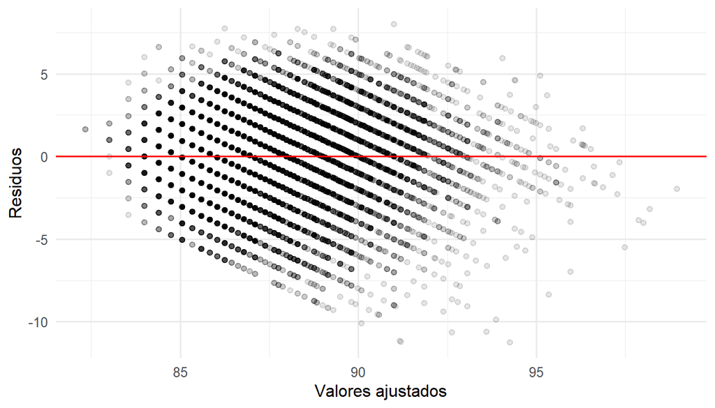

Diagnóstico de residuos del modelo lineal.

```r
tibble(fit = fitted(m), res = resid(m)) |> slice_sample(n = 20000) |>
  ggplot(aes(fit, res)) + geom_point(alpha = .1) + geom_hline(yintercept = 0, colour = "red") +
  labs(x = "Valores ajustados", y = "Residuos")
```

# 6 Descriptores de sabor: texto (Python)

Se calculó TF-IDF sobre las descripciones (unigramas y bigramas, sin stopwords genéricas del dominio) y, para cada banda de puntuación, los términos con mayor diferencia respecto del promedio global.

**Código**

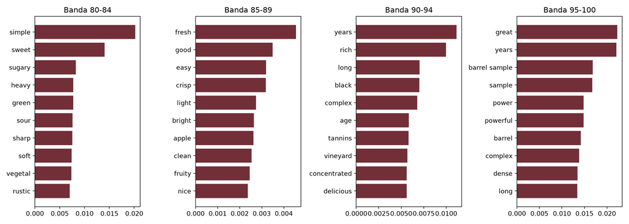

Figura 5: Términos más distintivos por banda de puntuación.

```python
import matplotlib.pyplot as plt

terms = pd.read_csv(root / "data/processed/terms_by_band.csv")
bands = terms["points_band"].unique()
fig, axes = plt.subplots(1, len(bands), figsize=(14, 5), sharex=False)
for ax, b in zip(axes, bands):
    t = terms[terms.points_band == b].nlargest(10, "score").iloc[::-1]
    ax.barh(t["term"], t["score"], color="#722F37")
    ax.set_title(f"Banda {b}")
plt.tight_layout()
plt.show()
```

Los vinos de 80-84 se describen con términos como *simple*, *sweet* o *sugary*; los de 95-100 incluyen *great*, *years* (potencial de guarda) y *barrel sample*.

# 7 Integración R y Python

Los resultados de Python se consumen en R y viceversa mediante `reticulate`:

**Código**

```python
resumen_py = pd.read_csv(root / "data/processed/country_summary.csv").head(10)
```

**Código**

```r
py$resumen_py |> kable(digits = 2, caption = "Tabla creada en Python, mostrada desde R")
```

Tabla creada en Python, mostrada desde R

| country | n | avg_points | median_price | avg_value |
| --- | --- | --- | --- | --- |
| US | 40531 | 87.91 | 28 | -0.24 |
| Italy | 14847 | 88.39 | 26 | 0.25 |
| France | 14452 | 88.92 | 25 | 0.33 |
| Spain | 5443 | 86.76 | 17 | -0.36 |
| Chile | 3735 | 86.28 | 14 | -0.17 |
| Portugal | 3507 | 88.12 | 17 | 1.20 |
| Argentina | 3446 | 86.08 | 15 | -0.51 |
| Australia | 3152 | 87.96 | 20 | 0.39 |
| Austria | 1957 | 89.38 | 24 | 1.43 |
| New Zealand | 1863 | 87.64 | 20 | 0.23 |

# 8 Discusión

- La puntuación y el precio se asocian positivamente (correlación de Spearman cercana a 0,6), pero con rendimientos decrecientes: subir de 85 a 90 puntos cuesta mucho menos que de 95 a 100.
- Los países difieren en puntuación, aunque el tamaño del efecto es pequeño frente a la variabilidad dentro de cada país.
- Las mejores relaciones calidad-precio aparecen en variedades poco conocidas (p. ej., Portuguese Red, Grüner Veltliner).
- **Limitaciones:** sesgo de selección (solo 80+), un único medio, sin dimensión temporal y precios sin fecha. Las conclusiones describen asociaciones, no causalidad.

# 9 Conclusiones

1. La limpieza fue crítica: más de un tercio de las filas originales eran duplicados.
2. El precio explica una parte importante pero no total de la puntuación.
3. Existen variedades con puntuación superior a la esperada para su precio.
4. El lenguaje de las reseñas cambia de forma sistemática con la puntuación.
5. El dashboard interactivo (Power BI) permite explorar estas relaciones por país, variedad y segmento de precio.

# 10 Referencias

- Thoutt, Z. *Wine Reviews*. Kaggle. https://www.kaggle.com/datasets/zynicide/wine-reviews
- R Core Team (2024). *R: A Language and Environment for Statistical Computing*.
- Pedregosa et al. (2011). Scikit-learn: Machine Learning in Python. *JMLR* 12.

# 11 Anexos

## 11.1 Información de sesión

**Código**

**Código**

```python
import sys, pandas, sklearn, matplotlib
print(sys.version); print("pandas", pandas.__version__, "| scikit-learn", sklearn.__version__)
```

```
3.13.3 (tags/v3.13.3:6280bb5, Apr  8 2025, 14:47:33) [MSC v.1943 64 bit (AMD64)]
pandas 3.0.5 | scikit-learn 1.9.0
```